# **General Overview**

#### Prod Taken vs Product Pitched

```
ProdTaken          0    1   All
ProductPitched
All             3968  920  4888
Basic           1290  552  1842
Deluxe          1528  204  1732
Standard         618  124   742
King             210   20   230
Super Deluxe     322   20   342
------------------------------------------------------------------------------------------------------------------------
```

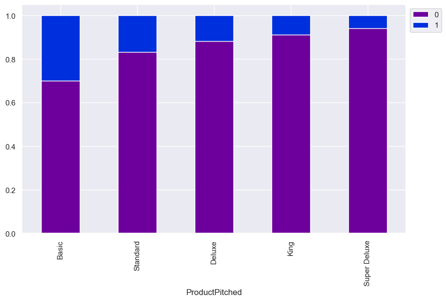

```python
# Stacked Barplot of Prod_Taken in comparison to ProductPitched
stacked_barplot(df, "ProductPitched", "ProdTaken")
```

*Observations*

- *The Basic Package is the most popular*
- *Standard and Deluxe are following.
- *Very few customers purchased Super Deluxe product.*

#### Prod Taken vs Designation

```
ProdTaken          0    1   All
Designation
All             3968  920  4888
Executive       1290  552  1842
Manager         1528  204  1732
Senior Manager   618  124   742
AVP              322   20   342
VP               210   20   230
------------------------------------------------------------------------------------------------------------------------
```

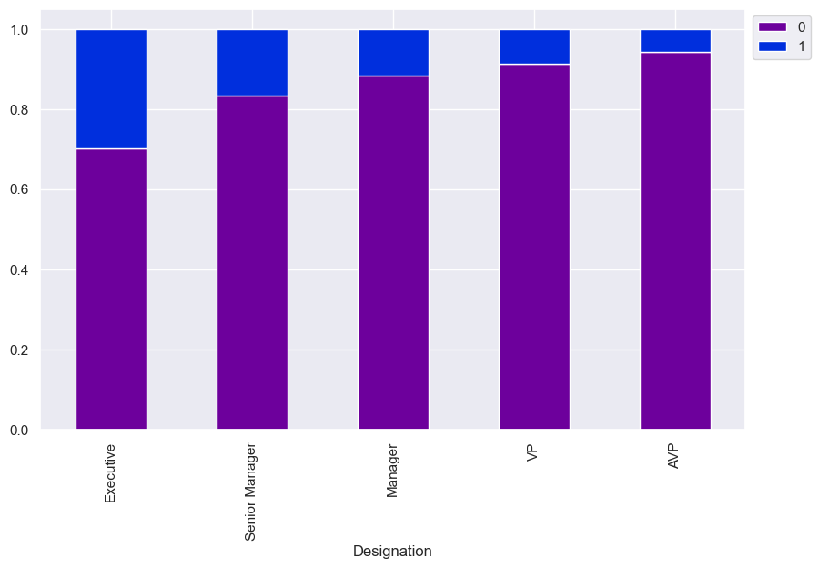

```python
# Stacked Barplot of Prod_Taken in comparison to Designation
stacked_barplot(df, "Designation", "ProdTaken")
```

*Observations*

- *Executives are most likely to buy the products*
- *Followed by Senior managers and Managers.*
- *Very few AVPs purchased the product.*

#### Prod Taken vs Age_Bin

```
ProdTaken     0    1   All
Age_Bin
All        3968  920  4888
31-40      1805  346  2151
18-30       774  341  1115
41-50       929  144  1073
50+         460   89   549
------------------------------------------------------------------------------------------------------------------------
```

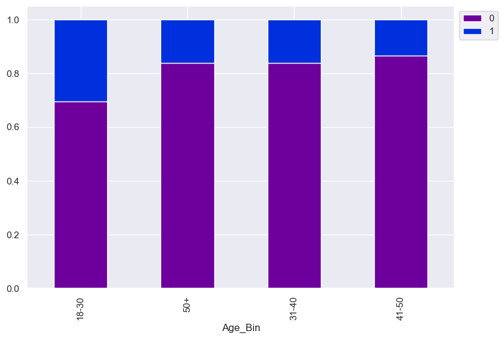

```python
# Stacked Barplot of Prod_Taken in comparison to Age_Bin
stacked_barplot(df, "Age_Bin", "ProdTaken")
```

*Observations*

- *Again we see flexibility at play. Younger people are more flexible. The Business should target more people in the 18-30 category.*

#### Prod Taken vs Duration of Pitch

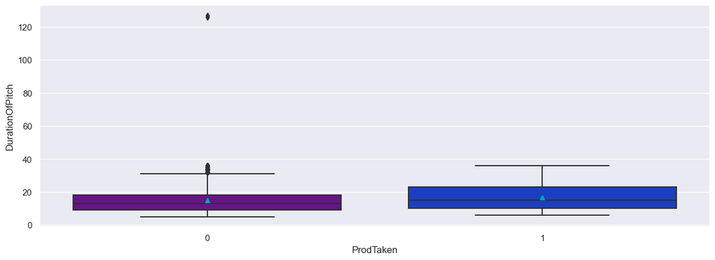

```python
# Boxplot of Personal_Loan in comparison to Experience
plt.figure(figsize=(15, 5))
sns.boxplot(data=df, x="ProdTaken", y="DurationOfPitch", showmeans=True)
plt.show()
```

*Observations*

- *The mean DurationofPitch for both classed of ProdTaken is almost equal. We see there are many outliers in Class "0" of ProdTaken, suggesting that longer pitch durations does not lead to product purchase.*

#### Prod Taken vs Monthly Income

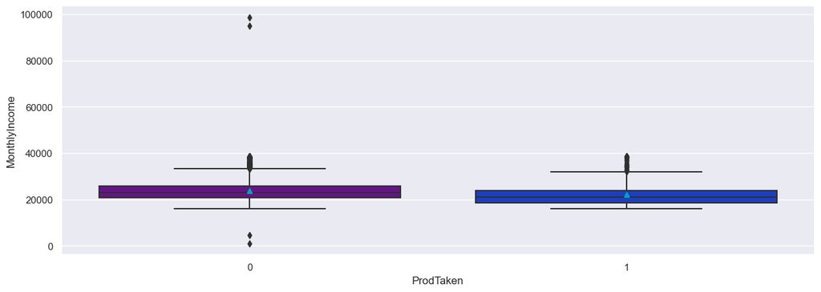

```
ProdTaken      0    1   All
Income_Bin
All         3968  920  4888
10K+ - 25K  2785  743  3528
25K+ - 50K  1179  177  1356
<10K           2    0     2
80K+           2    0     2
------------------------------------------------------------------------------------------------------------------------
```

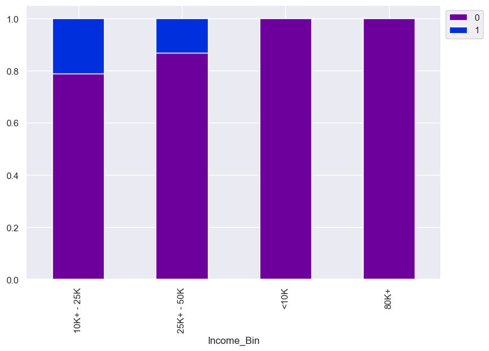

```python
# Boxplot of Personal_Loan in comparison to MonthlyIncome
plt.figure(figsize=(15, 5))
sns.boxplot(data=df, x="ProdTaken", y="MonthlyIncome", showmeans=True)
plt.show()

# Stacked Barplot of Prod_Taken in comparison to Income_Bin
stacked_barplot(df, "Income_Bin", "ProdTaken")
```

*Observations*

- *`MonthlyIncome` variable has several outliers in the higher end for both ProdTaken classes and very few in low end of Class "0".*
- *Only Customers with Income in the categories 10k-25k and 25k-50k purchased the products,*

#### Customer Profiles by Travel Package

```python
df[(df["ProductPitched"] == "Basic") & (df["ProdTaken"] == 1)].describe(include="all").T
```

|  | count | unique | top | freq | mean | std | min | 25% | 50% | 75% | max |
| --- | --- | --- | --- | --- | --- | --- | --- | --- | --- | --- | --- |
| ProdTaken | 552.0 | NaN | NaN | NaN | 1.0 | 0.0 | 1.0 | 1.0 | 1.0 | 1.0 | 1.0 |
| Age | 552.0 | NaN | NaN | NaN | 31.336957 | 8.762787 | 18.0 | 26.0 | 30.0 | 34.0 | 59.0 |
| TypeofContact | 552 | 2 | Self Enquiry | 358 | NaN | NaN | NaN | NaN | NaN | NaN | NaN |
| CityTier | 552.0 | NaN | NaN | NaN | 1.51087 | 0.832566 | 1.0 | 1.0 | 1.0 | 2.0 | 3.0 |
| DurationOfPitch | 552.0 | NaN | NaN | NaN | 15.690217 | 7.779636 | 6.0 | 9.0 | 13.5 | 21.0 | 36.0 |
| Occupation | 552 | 4 | Salaried | 260 | NaN | NaN | NaN | NaN | NaN | NaN | NaN |
| Gender | 552 | 2 | Male | 344 | NaN | NaN | NaN | NaN | NaN | NaN | NaN |
| NumberOfPersonVisiting | 552.0 | NaN | NaN | NaN | 2.905797 | 0.701439 | 2.0 | 2.0 | 3.0 | 3.0 | 4.0 |
| NumberOfFollowups | 552.0 | NaN | NaN | NaN | 3.951087 | 0.963658 | 1.0 | 3.0 | 4.0 | 5.0 | 6.0 |
| ProductPitched | 552 | 1 | Basic | 552 | NaN | NaN | NaN | NaN | NaN | NaN | NaN |
| PreferredPropertyStar | 552.0 | NaN | NaN | NaN | 3.771739 | 0.861812 | 3.0 | 3.0 | 3.0 | 5.0 | 5.0 |
| MaritalStatus | 552 | 4 | Single | 230 | NaN | NaN | NaN | NaN | NaN | NaN | NaN |
| NumberOfTrips | 552.0 | NaN | NaN | NaN | 3.224638 | 2.072263 | 1.0 | 2.0 | 3.0 | 3.25 | 20.0 |
| Passport | 552.0 | NaN | NaN | NaN | 0.583333 | 0.493454 | 0.0 | 0.0 | 1.0 | 1.0 | 1.0 |
| PitchSatisfactionScore | 552.0 | NaN | NaN | NaN | 3.213768 | 1.353074 | 1.0 | 2.0 | 3.0 | 4.0 | 5.0 |
| OwnCar | 552.0 | NaN | NaN | NaN | 0.572464 | 0.49517 | 0.0 | 0.0 | 1.0 | 1.0 | 1.0 |
| NumberOfChildrenVisiting | 552.0 | NaN | NaN | NaN | 1.221014 | 0.865801 | 0.0 | 1.0 | 1.0 | 2.0 | 3.0 |
| Designation | 552 | 1 | Executive | 552 | NaN | NaN | NaN | NaN | NaN | NaN | NaN |
| MonthlyIncome | 552.0 | NaN | NaN | NaN | 20183.507246 | 3245.115747 | 16009.0 | 17581.25 | 20689.0 | 21365.75 | 37868.0 |
| Age_Bin | 552 | 4 | 18-30 | 289 | NaN | NaN | NaN | NaN | NaN | NaN | NaN |
| Income_Bin | 552 | 2 | 10K+ - 25K | 527 | NaN | NaN | NaN | NaN | NaN | NaN | NaN |

```python
df[(df["ProductPitched"] == "Deluxe") & (df["ProdTaken"] == 1)].describe(
    include="all"
).T
```

|  | count | unique | top | freq | mean | std | min | 25% | 50% | 75% | max |
| --- | --- | --- | --- | --- | --- | --- | --- | --- | --- | --- | --- |
| ProdTaken | 204.0 | NaN | NaN | NaN | 1.0 | 0.0 | 1.0 | 1.0 | 1.0 | 1.0 | 1.0 |
| Age | 204.0 | NaN | NaN | NaN | 37.593137 | 8.348101 | 21.0 | 32.0 | 36.0 | 43.25 | 59.0 |
| TypeofContact | 204 | 2 | Self Enquiry | 136 | NaN | NaN | NaN | NaN | NaN | NaN | NaN |
| CityTier | 204.0 | NaN | NaN | NaN | 2.411765 | 0.913532 | 1.0 | 1.0 | 3.0 | 3.0 | 3.0 |
| DurationOfPitch | 204.0 | NaN | NaN | NaN | 18.382353 | 8.885749 | 6.0 | 12.0 | 15.0 | 26.0 | 36.0 |
| Occupation | 204 | 3 | Small Business | 108 | NaN | NaN | NaN | NaN | NaN | NaN | NaN |
| Gender | 204 | 2 | Male | 134 | NaN | NaN | NaN | NaN | NaN | NaN | NaN |
| NumberOfPersonVisiting | 204.0 | NaN | NaN | NaN | 2.95098 | 0.707141 | 2.0 | 2.0 | 3.0 | 3.0 | 4.0 |
| NumberOfFollowups | 204.0 | NaN | NaN | NaN | 3.970588 | 1.040613 | 1.0 | 3.0 | 4.0 | 5.0 | 6.0 |
| ProductPitched | 204 | 1 | Deluxe | 204 | NaN | NaN | NaN | NaN | NaN | NaN | NaN |
| PreferredPropertyStar | 204.0 | NaN | NaN | NaN | 3.696078 | 0.857183 | 3.0 | 3.0 | 3.0 | 5.0 | 5.0 |
| MaritalStatus | 204 | 4 | Married | 68 | NaN | NaN | NaN | NaN | NaN | NaN | NaN |
| NumberOfTrips | 204.0 | NaN | NaN | NaN | 3.696078 | 2.013693 | 1.0 | 2.0 | 3.0 | 5.0 | 8.0 |
| Passport | 204.0 | NaN | NaN | NaN | 0.490196 | 0.501134 | 0.0 | 0.0 | 0.0 | 1.0 | 1.0 |
| PitchSatisfactionScore | 204.0 | NaN | NaN | NaN | 3.039216 | 1.27825 | 1.0 | 2.0 | 3.0 | 4.0 | 5.0 |
| OwnCar | 204.0 | NaN | NaN | NaN | 0.607843 | 0.489432 | 0.0 | 0.0 | 1.0 | 1.0 | 1.0 |
| NumberOfChildrenVisiting | 204.0 | NaN | NaN | NaN | 1.171569 | 0.839291 | 0.0 | 1.0 | 1.0 | 2.0 | 3.0 |
| Designation | 204 | 1 | Manager | 204 | NaN | NaN | NaN | NaN | NaN | NaN | NaN |
| MonthlyIncome | 204.0 | NaN | NaN | NaN | 23098.088235 | 3512.132935 | 17086.0 | 20764.0 | 22922.0 | 24455.0 | 38525.0 |
| Age_Bin | 204 | 4 | 31-40 | 109 | NaN | NaN | NaN | NaN | NaN | NaN | NaN |
| Income_Bin | 204 | 2 | 10K+ - 25K | 170 | NaN | NaN | NaN | NaN | NaN | NaN | NaN |

```python
df[(df["ProductPitched"] == "Standard") & (df["ProdTaken"] == 1)].describe(
    include="all"
).T
```

|  | count | unique | top | freq | mean | std | min | 25% | 50% | 75% | max |
| --- | --- | --- | --- | --- | --- | --- | --- | --- | --- | --- | --- |
| ProdTaken | 124.0 | NaN | NaN | NaN | 1.0 | 0.0 | 1.0 | 1.0 | 1.0 | 1.0 | 1.0 |
| Age | 124.0 | NaN | NaN | NaN | 40.983871 | 9.840173 | 19.0 | 33.0 | 38.0 | 49.0 | 60.0 |
| TypeofContact | 124 | 2 | Self Enquiry | 92 | NaN | NaN | NaN | NaN | NaN | NaN | NaN |
| CityTier | 124.0 | NaN | NaN | NaN | 2.096774 | 0.966255 | 1.0 | 1.0 | 3.0 | 3.0 | 3.0 |
| DurationOfPitch | 124.0 | NaN | NaN | NaN | 19.016129 | 9.028396 | 6.0 | 11.0 | 17.0 | 29.0 | 36.0 |
| Occupation | 124 | 3 | Small Business | 58 | NaN | NaN | NaN | NaN | NaN | NaN | NaN |
| Gender | 124 | 2 | Male | 76 | NaN | NaN | NaN | NaN | NaN | NaN | NaN |
| NumberOfPersonVisiting | 124.0 | NaN | NaN | NaN | 2.967742 | 0.709236 | 2.0 | 2.0 | 3.0 | 3.0 | 4.0 |
| NumberOfFollowups | 124.0 | NaN | NaN | NaN | 3.935484 | 0.908335 | 1.0 | 3.0 | 4.0 | 4.25 | 6.0 |
| ProductPitched | 124 | 1 | Standard | 124 | NaN | NaN | NaN | NaN | NaN | NaN | NaN |
| PreferredPropertyStar | 124.0 | NaN | NaN | NaN | 3.725806 | 0.877345 | 3.0 | 3.0 | 3.0 | 5.0 | 5.0 |
| MaritalStatus | 124 | 4 | Married | 56 | NaN | NaN | NaN | NaN | NaN | NaN | NaN |
| NumberOfTrips | 124.0 | NaN | NaN | NaN | 3.016129 | 1.807769 | 1.0 | 2.0 | 2.5 | 4.0 | 8.0 |
| Passport | 124.0 | NaN | NaN | NaN | 0.387097 | 0.489062 | 0.0 | 0.0 | 0.0 | 1.0 | 1.0 |
| PitchSatisfactionScore | 124.0 | NaN | NaN | NaN | 3.467742 | 1.30935 | 1.0 | 3.0 | 3.0 | 5.0 | 5.0 |
| OwnCar | 124.0 | NaN | NaN | NaN | 0.66129 | 0.475191 | 0.0 | 0.0 | 1.0 | 1.0 | 1.0 |
| NumberOfChildrenVisiting | 124.0 | NaN | NaN | NaN | 1.120968 | 0.89799 | 0.0 | 0.0 | 1.0 | 2.0 | 3.0 |
| Designation | 124 | 1 | Senior Manager | 124 | NaN | NaN | NaN | NaN | NaN | NaN | NaN |
| MonthlyIncome | 124.0 | NaN | NaN | NaN | 26035.419355 | 3593.290353 | 17372.0 | 23974.75 | 25711.0 | 28628.0 | 38395.0 |
| Age_Bin | 124 | 4 | 31-40 | 48 | NaN | NaN | NaN | NaN | NaN | NaN | NaN |
| Income_Bin | 124 | 2 | 25K+ - 50K | 82 | NaN | NaN | NaN | NaN | NaN | NaN | NaN |

```python
df[(df["ProductPitched"] == "Super Deluxe") & (df["ProdTaken"] == 1)].describe(
    include="all"
).T
```

|  | count | unique | top | freq | mean | std | min | 25% | 50% | 75% | max |
| --- | --- | --- | --- | --- | --- | --- | --- | --- | --- | --- | --- |
| ProdTaken | 20.0 | NaN | NaN | NaN | 1.0 | 0.0 | 1.0 | 1.0 | 1.0 | 1.0 | 1.0 |
| Age | 20.0 | NaN | NaN | NaN | 43.5 | 4.83953 | 39.0 | 40.0 | 42.0 | 45.25 | 56.0 |
| TypeofContact | 20 | 2 | Company Invited | 16 | NaN | NaN | NaN | NaN | NaN | NaN | NaN |
| CityTier | 20.0 | NaN | NaN | NaN | 2.6 | 0.820783 | 1.0 | 3.0 | 3.0 | 3.0 | 3.0 |
| DurationOfPitch | 20.0 | NaN | NaN | NaN | 18.5 | 7.330542 | 8.0 | 15.0 | 18.5 | 20.0 | 31.0 |
| Occupation | 20 | 2 | Salaried | 16 | NaN | NaN | NaN | NaN | NaN | NaN | NaN |
| Gender | 20 | 2 | Male | 16 | NaN | NaN | NaN | NaN | NaN | NaN | NaN |
| NumberOfPersonVisiting | 20.0 | NaN | NaN | NaN | 2.7 | 0.656947 | 2.0 | 2.0 | 3.0 | 3.0 | 4.0 |
| NumberOfFollowups | 20.0 | NaN | NaN | NaN | 3.1 | 1.618967 | 1.0 | 2.0 | 3.0 | 4.0 | 6.0 |
| ProductPitched | 20 | 1 | Super Deluxe | 20 | NaN | NaN | NaN | NaN | NaN | NaN | NaN |
| PreferredPropertyStar | 20.0 | NaN | NaN | NaN | 3.6 | 0.820783 | 3.0 | 3.0 | 3.0 | 4.0 | 5.0 |
| MaritalStatus | 20 | 3 | Single | 10 | NaN | NaN | NaN | NaN | NaN | NaN | NaN |
| NumberOfTrips | 20.0 | NaN | NaN | NaN | 3.25 | 2.425197 | 1.0 | 1.0 | 2.0 | 5.25 | 8.0 |
| Passport | 20.0 | NaN | NaN | NaN | 0.6 | 0.502625 | 0.0 | 0.0 | 1.0 | 1.0 | 1.0 |
| PitchSatisfactionScore | 20.0 | NaN | NaN | NaN | 3.8 | 1.005249 | 3.0 | 3.0 | 3.0 | 5.0 | 5.0 |
| OwnCar | 20.0 | NaN | NaN | NaN | 1.0 | 0.0 | 1.0 | 1.0 | 1.0 | 1.0 | 1.0 |
| NumberOfChildrenVisiting | 20.0 | NaN | NaN | NaN | 1.2 | 0.833509 | 0.0 | 1.0 | 1.0 | 2.0 | 3.0 |
| Designation | 20 | 1 | AVP | 20 | NaN | NaN | NaN | NaN | NaN | NaN | NaN |
| MonthlyIncome | 20.0 | NaN | NaN | NaN | 29823.8 | 3520.426404 | 21151.0 | 28129.5 | 29802.5 | 31997.25 | 37502.0 |
| Age_Bin | 20 | 3 | 41-50 | 12 | NaN | NaN | NaN | NaN | NaN | NaN | NaN |
| Income_Bin | 20 | 2 | 25K+ - 50K | 18 | NaN | NaN | NaN | NaN | NaN | NaN | NaN |

```python
df[(df["ProductPitched"] == "King") & (df["ProdTaken"] == 1)].describe(include="all").T
```

|  | count | unique | top | freq | mean | std | min | 25% | 50% | 75% | max |
| --- | --- | --- | --- | --- | --- | --- | --- | --- | --- | --- | --- |
| ProdTaken | 20.0 | NaN | NaN | NaN | 1.0 | 0.0 | 1.0 | 1.0 | 1.0 | 1.0 | 1.0 |
| Age | 20.0 | NaN | NaN | NaN | 48.9 | 9.618513 | 27.0 | 42.0 | 52.5 | 56.0 | 59.0 |
| TypeofContact | 20 | 1 | Self Enquiry | 20 | NaN | NaN | NaN | NaN | NaN | NaN | NaN |
| CityTier | 20.0 | NaN | NaN | NaN | 1.8 | 1.005249 | 1.0 | 1.0 | 1.0 | 3.0 | 3.0 |
| DurationOfPitch | 20.0 | NaN | NaN | NaN | 10.5 | 4.135851 | 8.0 | 8.0 | 9.0 | 9.0 | 19.0 |
| Occupation | 20 | 3 | Small Business | 12 | NaN | NaN | NaN | NaN | NaN | NaN | NaN |
| Gender | 20 | 2 | Female | 12 | NaN | NaN | NaN | NaN | NaN | NaN | NaN |
| NumberOfPersonVisiting | 20.0 | NaN | NaN | NaN | 2.9 | 0.718185 | 2.0 | 2.0 | 3.0 | 3.0 | 4.0 |
| NumberOfFollowups | 20.0 | NaN | NaN | NaN | 4.3 | 1.128576 | 3.0 | 3.0 | 4.0 | 5.0 | 6.0 |
| ProductPitched | 20 | 1 | King | 20 | NaN | NaN | NaN | NaN | NaN | NaN | NaN |
| PreferredPropertyStar | 20.0 | NaN | NaN | NaN | 3.6 | 0.680557 | 3.0 | 3.0 | 3.5 | 4.0 | 5.0 |
| MaritalStatus | 20 | 3 | Single | 8 | NaN | NaN | NaN | NaN | NaN | NaN | NaN |
| NumberOfTrips | 20.0 | NaN | NaN | NaN | 3.35 | 1.785173 | 1.0 | 2.0 | 3.0 | 3.25 | 7.0 |
| Passport | 20.0 | NaN | NaN | NaN | 0.6 | 0.502625 | 0.0 | 0.0 | 1.0 | 1.0 | 1.0 |
| PitchSatisfactionScore | 20.0 | NaN | NaN | NaN | 3.3 | 1.218282 | 1.0 | 3.0 | 3.0 | 4.0 | 5.0 |
| OwnCar | 20.0 | NaN | NaN | NaN | 0.9 | 0.307794 | 0.0 | 1.0 | 1.0 | 1.0 | 1.0 |
| NumberOfChildrenVisiting | 20.0 | NaN | NaN | NaN | 1.35 | 0.812728 | 0.0 | 1.0 | 1.0 | 2.0 | 3.0 |
| Designation | 20 | 1 | VP | 20 | NaN | NaN | NaN | NaN | NaN | NaN | NaN |
| MonthlyIncome | 20.0 | NaN | NaN | NaN | 34672.1 | 5577.603833 | 17517.0 | 34470.25 | 34859.0 | 38223.0 | 38537.0 |
| Age_Bin | 20 | 3 | 50+ | 12 | NaN | NaN | NaN | NaN | NaN | NaN | NaN |
| Income_Bin | 20 | 2 | 25K+ - 50K | 18 | NaN | NaN | NaN | NaN | NaN | NaN | NaN |

*Observations*

**Basic package:** Most of the customer have Monthly income < 25000, Age is in range of 26-30, Designation as Executive belong to City tier 1, are salaried and single males . Customer contacted the company.Married customers also prefer this basic package.

**Deluxe package:** Most of the customer have Monthly income < 25000, Age is in range of 31-40, Designation as Managers belong to city tier 3 and occupation is small business and married .Customer contacted the company. City tier 1 and divorced customers also preferred this package. There are 204 customers that signed up for this package.

**Standard package:** Most of the customer have Monthly income <30000,Age is in range of 31-40 , Designation as Senior Manager, is married , from tier city 3,and occupation is small business. majority of them had self inquired. There are 124 customers that signed up for this package.

**SuperDeluxe:** Most of the customer have Monthly income < 35000, Age is in range 41-50, Designation as AVP, belongs to tier city 3 and is Single, male and occupation is salaried. Majority of them were company invited. There are 20 customers that signed up for this package.

**King :** Most of the customer have Monthly income in range of 30000-35000, age range in 51-60, Designation as VP. Belong to city tier 1 and are single female and Occupation is small business.Females buy this package more than men. There are 20 customers that signed up for this package.

## More Data Preprocessing

### Outlier Detection and Treatment

We will identify and handle outliers in the data to improve the performance of our machine learning models.

We will treat all the outliers using capping & flooring, as opposed to deleting the extreme cases.

```python
# Treating outliers by flooring and capping
def outliers_treatment(df, col):
    Q1 = df[col].quantile(0.25)  # 25th quantile
    Q3 = df[col].quantile(0.75)  # 75th quantile
    IQR = Q3 - Q1
    Lower_Whisker = Q1 - 1.5 * IQR
    Upper_Whisker = Q3 + 1.5 * IQR

    # All the values samller than Lower_Whisker will be assigned value of Lower_whisker
    # And all the values above upper_whishker will be assigned value of upper_Whisker
    df[col] = np.clip(df[col], Lower_Whisker, Upper_Whisker)

    return df


def treat_outliers(df, col_list):
    for c in col_list:
        df = outliers_treatment(df, c)

    return df
```

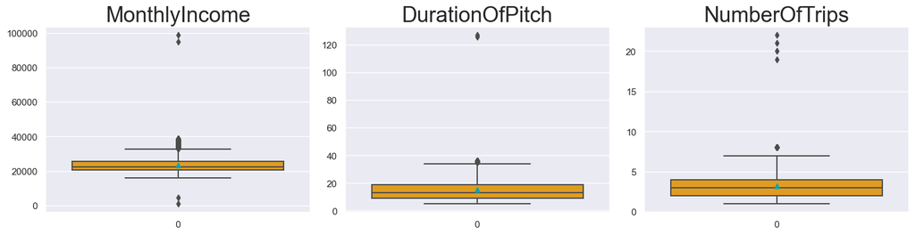

```python
# -----
# Create BoxPlots of Numerical columns
# This shows where outliers are present
# -----

num_col = ["MonthlyIncome", "DurationOfPitch", "NumberOfTrips"]

plt.figure(figsize=(15, 35))
for i in range(len(num_col)):
    plt.subplot(10, 3, i + 1)
    sns.boxplot(df[num_col[i]], showmeans=True, color="orange")
    plt.tight_layout()
    plt.title(num_col[i], fontsize=25)

plt.show()
```

*Observations*

- *As seen earlier, `MonthlyIncome`, `NumberOfTrips` & `DurationOfPitch` have outliers. These will be treated.*

```python
# -----
# Treating Outliers:
# We are treating outliers by flooring and capping
# -----
df = treat_outliers(df, num_col)
```

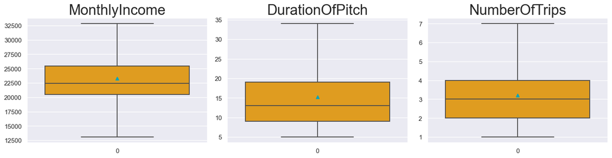

```python
# checking if the outliers are treated
plt.figure(figsize=(15, 35))
for i in range(len(num_col)):
    plt.subplot(10, 3, i + 1)
    sns.boxplot(df[num_col[i]], showmeans=True, color="orange")
    plt.tight_layout()
    plt.title(num_col[i], fontsize=25)

plt.show()
```

*Observations*

- *Outliers have been treated*
- *We will build the models with this treated dataset*

### Dropping Columns

Since the aim is to predict customers who are more likely to buy the product, we will drop the columns `DurationOfPitch`, `NumberOfFollowups`, `ProductPitched`, `PitchSatisfactionScore` as these columns would not be available at the time of prediction for new data.

```python
# Dropping DurationOfPitch, NumberOfFollowups, ProductPitched, PitchSatisfactionScore
df.drop(
    columns=[
        "DurationOfPitch",
        "NumberOfFollowups",
        "ProductPitched",
        "PitchSatisfactionScore",
    ],
    inplace=True,
)
```

Since we are done with EDA, the features we created during Binning (`Age_Bin` & `Income_Bin`) are no longer needed. We will drop them.

```python
# Dropping Age_Bin & Income_Bin
df.drop(columns=["Age_Bin", "Income_Bin"], inplace=True)
```

## **Data Preparation for Modeling**

### Define Dependent & Independent Variables

```python
# Defining X and y variables
X = df.drop(columns=["ProdTaken"])

y = df[["ProdTaken"]]

print(X.shape)
print(y.shape)
```

```
(4888, 14)
(4888, 1)
```

### Creating Dummy Variables

```python
# Creating Dummy Variabls for the Categorical Columns (CityTier is treated as Categorical)
X = pd.get_dummies(
    X,
    columns=[
        "TypeofContact",
        "Occupation",
        "Gender",
        "MaritalStatus",
        "Designation",
        "CityTier",
    ],
    drop_first=True,
)
```

### Convert Integer Column Types to Float

```python
# converting data types of columns to float
for column in ["NumberOfPersonVisiting", "Passport", "OwnCar"]:
    X[column] = X[column].astype("float")
```

```python
X.info()
```

```
<class 'pandas.core.frame.DataFrame'>
RangeIndex: 4888 entries, 0 to 4887
Data columns (total 22 columns):
 #   Column                      Non-Null Count  Dtype
---  ------                      --------------  -----
 0   Age                         4888 non-null   float64
 1   NumberOfPersonVisiting      4888 non-null   float64
 2   PreferredPropertyStar       4888 non-null   float64
 3   NumberOfTrips               4888 non-null   float64
 4   Passport                    4888 non-null   float64
 5   OwnCar                      4888 non-null   float64
 6   NumberOfChildrenVisiting    4888 non-null   float64
 7   MonthlyIncome               4888 non-null   float64
 8   TypeofContact_Self Enquiry  4888 non-null   uint8
 9   Occupation_Large Business   4888 non-null   uint8
 10  Occupation_Salaried         4888 non-null   uint8
 11  Occupation_Small Business   4888 non-null   uint8
 12  Gender_Male                 4888 non-null   uint8
 13  MaritalStatus_Married       4888 non-null   uint8
 14  MaritalStatus_Single        4888 non-null   uint8
 15  MaritalStatus_Unmarried     4888 non-null   uint8
 16  Designation_Executive       4888 non-null   uint8
 17  Designation_Manager         4888 non-null   uint8
 18  Designation_Senior Manager  4888 non-null   uint8
 19  Designation_VP              4888 non-null   uint8
 20  CityTier_2                  4888 non-null   uint8
 21  CityTier_3                  4888 non-null   uint8
dtypes: float64(8), uint8(14)
memory usage: 372.5 KB
```

### Split the Data into Train and Test

```python
# Split the data into 70% train and 30% test

X_train, X_test, y_train, y_test = train_test_split(
    X, y, test_size=0.3, random_state=1, stratify=y
)
```

```python
print("\nPercentage of classes in original set : ")
print(y.value_counts(normalize=True) * 100)
print("\nPercentage of classes in training set : ")
print(y_train.value_counts(normalize=True) * 100)
print("\nPercentage of classes in test set : ")
print(y_test.value_counts(normalize=True) * 100)
```

```
Percentage of classes in original set :
ProdTaken
0            81.178396
1            18.821604
dtype: float64

Percentage of classes in training set :
ProdTaken
0            81.175095
1            18.824905
dtype: float64

Percentage of classes in test set :
ProdTaken
0            81.186094
1            18.813906
dtype: float64
```

**Observation**

- *The split is consistent.*

# **Model Building**

## Model Evaluation Criteria

**The model can make wrong predictions as:**

1. Predicting a customer will buy the product and the customer doesn't buy - Loss of resources
2. Predicting a customer will not buy the product and the customer would have bought - Loss of opportunity

**Which case is more important?**

- Predicting that customer will not buy the product but he would have bought i.e. losing on a potential source of income for the company because that customer will not be targeted by the marketing team when he should be targeted.

**How to reduce this loss i.e need to reduce False Negatives?**

- We know that the Recall (Sensitivity or True Positive Recal (TPR)) is expressed as $Recall Score=\dfrac{TP}{TP+FN}$.
- The company wants Recall to be maximized, the greater the Recall lesser the chances of false negatives.
- The lower the FN the greater the Recall Score, the higher the chances of predicting the potential customers who will buy the travel packages.

```python
#
# User defined function to compute different metrics to check performance of a
# classification model built using sklearn
#
def model_performance_classification_sklearn(model, predictors, target):
    """
    Function to compute different metrics to check classification model performance

    model: classifier
    predictors: independent variables
    target: dependent variable
    """

    # predicting using the independent variables
    pred = model.predict(predictors)

    acc = accuracy_score(target, pred)  # to compute Accuracy
    recall = recall_score(target, pred)  # to compute Recall
    precision = precision_score(target, pred)  # to compute Precision
    f1 = f1_score(target, pred)  # to compute F1-score

    # creating a dataframe of metrics
    df_perf = pd.DataFrame(
        {
            "Accuracy": acc,
            "Recall": recall,
            "Precision": precision,
            "F1": f1,
        },
        index=[0],
    )

    return df_perf
```

```python
# defining a function to plot the confusion_matrix of a classification model built using sklearn
def confusion_matrix_sklearn(model, predictors, target):
    """
    To plot the confusion_matrix with percentages

    model: classifier
    predictors: independent variables
    target: dependent variable
    """
    y_pred = model.predict(predictors)
    cm = confusion_matrix(target, y_pred)
    labels = np.asarray(
        [
            ["{0:0.0f}".format(item) + "\n{0:.2%}".format(item / cm.flatten().sum())]
            for item in cm.flatten()
        ]
    ).reshape(2, 2)

    plt.figure(figsize=(6, 4))
    sns.heatmap(cm, annot=labels, fmt="")
    plt.ylabel("True label")
    plt.xlabel("Predicted label")
```

## **Building Decision Tree Classifier.**

### Decision Tree Model

```python
# Build Decision Tree Classifier Model
d_tree = DecisionTreeClassifier(random_state=1)

## Fit the decision tree model on X_train and y_train
d_tree.fit(X_train, y_train)
```

```
DecisionTreeClassifier(random_state=1)
```

### Model Performance Check

#### Checking model performance on training set

```python
# Calculating different metrics
d_tree_model_train_perf = model_performance_classification_sklearn(
    d_tree, X_train, y_train
)
print("Training performance:")
d_tree_model_train_perf
```

```
Training performance:
```

|  | Accuracy | Recall | Precision | F1 |
| --- | --- | --- | --- | --- |
| 0 | 1.0 | 1.0 | 1.0 | 1.0 |

#### Checking model performance on testing set

```python
# get the model performance on X_test and y_test using the above model
d_tree_model_test_perf = model_performance_classification_sklearn(
    d_tree, X_test, y_test
)
print("Testing performance:")
d_tree_model_test_perf
```

```
Testing performance:
```

|  | Accuracy | Recall | Precision | F1 |
| --- | --- | --- | --- | --- |
| 0 | 0.864349 | 0.663043 | 0.633218 | 0.647788 |

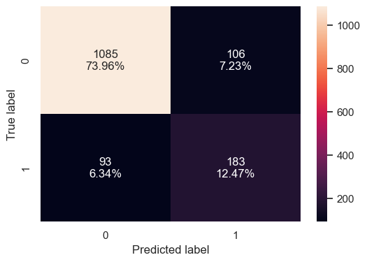

```python
# Confusion matrix for test data
confusion_matrix_sklearn(d_tree, X_test, y_test)
```

**Observations**

- *Decision tree is overfitting the training data as there is lot of disparity between test and train.*
- *Recall score for Test Data is 0.663. which is also not that high*

### Model Improvement: Decision Tree

Attemping to improve the model - Hypertuned Decision Tree Classifier.

```python
# Initialize classifier.
tuned_dtree = DecisionTreeClassifier(class_weight={0: 0.19, 1: 0.81}, random_state=1)

# Grid of parameters
parameters = {
    "max_depth": np.arange(2, 30),
    "min_samples_leaf": [1, 2, 5, 7, 10],
    "max_leaf_nodes": [2, 3, 5, 10, 15] + [None],
    "min_impurity_decrease": [0.0001, 0.001, 0.01, 0.1],
}

# Scoring Used
scorer = metrics.make_scorer(metrics.recall_score)

# Run the grid search
grid_obj = GridSearchCV(tuned_dtree, parameters, scoring=scorer, n_jobs=-1)
grid_obj = grid_obj.fit(X_train, y_train)

# Set the clf to the best combination of parameters
tuned_dtree = grid_obj.best_estimator_

# Complete the code to fit the above model on train data.
tuned_dtree.fit(X_train, y_train)
```

```
DecisionTreeClassifier(class_weight={0: 0.19, 1: 0.81}, max_depth=13,
                       min_impurity_decrease=0.001, random_state=1)
```

##### Check the performance of model on Training & Testing Sets for the Hypertuned Decision Tree

```python
# checking the model performance for training set
tuned_dtree_estimator_model_train_perf = model_performance_classification_sklearn(
    tuned_dtree, X_train, y_train
)
print("Training performance:")
tuned_dtree_estimator_model_train_perf
```

```
Training performance:
```

|  | Accuracy | Recall | Precision | F1 |
| --- | --- | --- | --- | --- |
| 0 | 0.813505 | 0.93323 | 0.502508 | 0.653261 |

```python
# checking the model performance for training set
tuned_dtree_estimator_model_test_perf = model_performance_classification_sklearn(
    tuned_dtree, X_test, y_test
)
print("Testing performance:")
tuned_dtree_estimator_model_test_perf
```

```
Testing performance:
```

|  | Accuracy | Recall | Precision | F1 |
| --- | --- | --- | --- | --- |
| 0 | 0.760736 | 0.789855 | 0.426614 | 0.554003 |

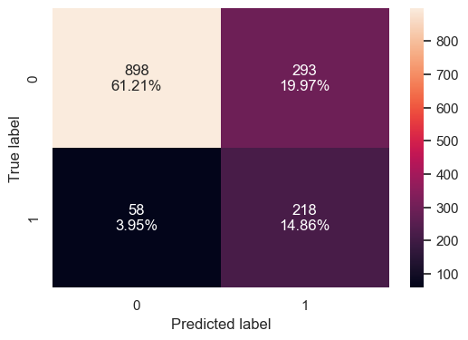

```python
# Confusion matrix for test data
confusion_matrix_sklearn(tuned_dtree, X_test, y_test)
```

**Observations**

- *Overfitting has decreased a little for the training data of Recall.*
- *Recall for the testing data has increased from 0.66 to 0.79.*
- *The performance values for Recalll are better on the tuned Decision Tree.*

### Visualizing the Hypertuned Decision Tree

```python
# Creating a list of column names

feature_names = X_train.columns.to_list()

plt.figure(figsize=(20, 30))
out = tree.plot_tree(
    tuned_dtree,
    feature_names=feature_names,
    filled=True,
    fontsize=9,
    node_ids=False,
    class_names=None,
)

# below code will add arrows to the decision tree split if they are missing
for o in out:
    arrow = o.arrow_patch
    if arrow is not None:
        arrow.set_edgecolor("black")
        arrow.set_linewidth(1)
plt.show()
```

[output not shown]

## **Building Ensemble Models.**

### Model Building: Random Forest Model

```python
# Build Random Forest Classifier Model
rfc = RandomForestClassifier(random_state=1)

## Fit the decision tree model on X_train and y_train
rfc.fit(X_train, y_train)
```

```
RandomForestClassifier(random_state=1)
```

### Model Performance Check

#### Checking model performance on training set

```python
# Calculating different metrics
rfc_model_train_perf = model_performance_classification_sklearn(rfc, X_train, y_train)
print("Training performance:")
rfc_model_train_perf
```

```
Training performance:
```

|  | Accuracy | Recall | Precision | F1 |
| --- | --- | --- | --- | --- |
| 0 | 1.0 | 1.0 | 1.0 | 1.0 |

#### Checking model performance on testing set

```python
# get the model performance on X_test and y_test using the above model
rfc_model_test_perf = model_performance_classification_sklearn(rfc, X_test, y_test)
print("Testing performance:")
rfc_model_test_perf
```

```
Testing performance:
```

|  | Accuracy | Recall | Precision | F1 |
| --- | --- | --- | --- | --- |
| 0 | 0.889571 | 0.467391 | 0.895833 | 0.614286 |

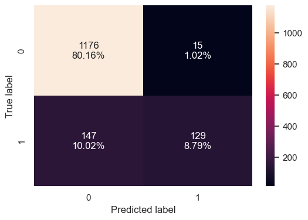

```python
# Confusion matrix for test data
confusion_matrix_sklearn(rfc, X_test, y_test)
```

**Observations**

- *The Random Forest is overfitting the training data. There is lot of disparity between test and train.*
- *Recall score for Test Data is 0.467. which is also not that high*

### Model Improvement: Random Forest

Attemping to improve the model - Hypertuned Random Forest Classifier.

```python
%%time

# Initialize Random Forest Classifier.
rf_tuned = RandomForestClassifier(
    class_weight={0: 0.18, 1: 0.82},
    random_state=1,
    oob_score=False,
    bootstrap=True,
    verbose=0,
    warm_start=True,
)

parameters = {
    "max_depth": list(np.arange(5, 30, 5)) + [None],
    "max_features": ["sqrt", "log2", "auto"],
    "min_samples_leaf": np.arange(1, 15, 5),
    "min_samples_split": np.arange(2, 20, 5),
    "n_estimators": np.arange(10, 110, 10),
}


# Run the grid search
grid_obj = GridSearchCV(rf_tuned, parameters, scoring="recall", cv=5, n_jobs=-1)
grid_obj = grid_obj.fit(X_train, np.ravel(y_train))

# Set the clf to the best combination of parameters
rf_tuned = grid_obj.best_estimator_

# fit the model on training data
rf_tuned.fit(X_train, y_train)
```

```
CPU times: user 9.1 s, sys: 1.55 s, total: 10.7 s
Wall time: 2min 45s
```

```
RandomForestClassifier(class_weight={0: 0.18, 1: 0.82}, max_depth=10,
                       min_samples_leaf=11, n_estimators=20, random_state=1,
                       warm_start=True)
```

### Model Performance Check

#### Checking model performance on training set

```python
# Calculating different metrics
rf_tuned_model_train_perf = model_performance_classification_sklearn(
    rf_tuned, X_train, y_train
)
print("Training performance:")
rf_tuned_model_train_perf
```

```
Training performance:
```

|  | Accuracy | Recall | Precision | F1 |
| --- | --- | --- | --- | --- |
| 0 | 0.849752 | 0.821429 | 0.570043 | 0.673028 |

#### Checking model performance on testing set

```python
# get the model performance on X_test and y_test using the above model
rf_tuned_model_test_perf = model_performance_classification_sklearn(
    rf_tuned, X_test, y_test
)
print("Testing performance:")
rf_tuned_model_test_perf
```

```
Testing performance:
```

|  | Accuracy | Recall | Precision | F1 |
| --- | --- | --- | --- | --- |
| 0 | 0.815269 | 0.695652 | 0.506596 | 0.58626 |

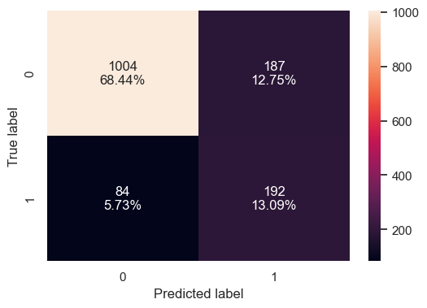

```python
# Confusion matrix for test data
confusion_matrix_sklearn(rf_tuned, X_test, y_test)
```

**Observations**

- *The Tuned Random Forest is more generalized than the untuned Random Forest.*
- *Recall score for Train and Test Data are 0.82 and 0.70 respectively*

### Model Building: Bagging

```python
# Using the Tuned Decision Tree to Build Bagging Classifier Model
bgc = BaggingClassifier(base_estimator=tuned_dtree, random_state=1)
# bgc = BaggingClassifier(random_state=1)

## Fit the Bagging model on X_train and y_train
bgc.fit(X_train, y_train)
```

```
BaggingClassifier(base_estimator=DecisionTreeClassifier(class_weight={0: 0.19,
                                                                      1: 0.81},
                                                        max_depth=13,
                                                        min_impurity_decrease=0.001,
                                                        random_state=1),
                  random_state=1)
```

### Model Performance Check

#### Checking model performance on training set

```python
# Calculating different metrics
bgc_model_train_perf = model_performance_classification_sklearn(bgc, X_train, y_train)
print("Training performance:")
bgc_model_train_perf
```

```
Training performance:
```

|  | Accuracy | Recall | Precision | F1 |
| --- | --- | --- | --- | --- |
| 0 | 0.905875 | 0.928571 | 0.684211 | 0.787879 |

#### Checking model performance on testing set

```python
# get the model performance on X_test and y_test using the above model
bgc_model_test_perf = model_performance_classification_sklearn(bgc, X_test, y_test)
print("Testing performance:")
bgc_model_test_perf
```

```
Testing performance:
```

|  | Accuracy | Recall | Precision | F1 |
| --- | --- | --- | --- | --- |
| 0 | 0.850034 | 0.699275 | 0.584848 | 0.636964 |

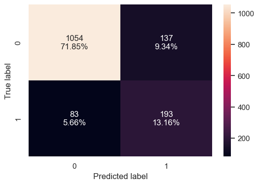

```python
# Confusion matrix for test data
confusion_matrix_sklearn(bgc, X_test, y_test)
```

**Observations**

- *The Bagging Clasifier does not generalise well on the data. There is lot of disparity between test and train.*
- *Recall score for Train and Test Data are 0.929 and 0.699 respectively*

### Model Improvement: Bagging

```python
# Choose the type of classifier.
bgc_tuned = BaggingClassifier(base_estimator=tuned_dtree, random_state=1)

# Grid of parameters to choose from
parameters = {
    "max_samples": [0.7, 0.8, 0.9, 1],
    "max_features": [0.7, 0.8, 0.9, 1],
    "n_estimators": [10, 20, 30, 40, 50],
}

# Type of scoring used to compare parameter combinations
acc_scorer = metrics.make_scorer(metrics.recall_score)

# Run the grid search
grid_obj = GridSearchCV(bgc_tuned, parameters, scoring=acc_scorer, cv=5)
grid_obj = grid_obj.fit(X_train, y_train)

# Set the clf to the best combination of parameters
bgc_tuned = grid_obj.best_estimator_

# Complete the code to fit the above model on training data
bgc_tuned.fit(X_train, y_train)
```

```
BaggingClassifier(base_estimator=DecisionTreeClassifier(class_weight={0: 0.19,
                                                                      1: 0.81},
                                                        max_depth=13,
                                                        min_impurity_decrease=0.001,
                                                        random_state=1),
                  max_features=0.8, max_samples=0.9, random_state=1)
```

### Model Performance Check

#### Checking model performance on training set

```python
# Calculating different metrics
bgc_tuned_model_train_perf = model_performance_classification_sklearn(
    bgc_tuned, X_train, y_train
)
print("Training performance:")
bgc_tuned_model_train_perf
```

```
Training performance:
```

|  | Accuracy | Recall | Precision | F1 |
| --- | --- | --- | --- | --- |
| 0 | 0.910845 | 0.889752 | 0.710037 | 0.7898 |

#### Checking model performance on testing set

```python
# get the model performance on X_test and y_test using the above model
bgc_tuned_model_test_perf = model_performance_classification_sklearn(
    bgc_tuned, X_test, y_test
)
print("Testing performance:")
bgc_tuned_model_test_perf
```

```
Testing performance:
```

|  | Accuracy | Recall | Precision | F1 |
| --- | --- | --- | --- | --- |
| 0 | 0.848671 | 0.644928 | 0.589404 | 0.615917 |

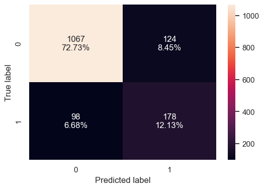

```python
# Confusion matrix for test data
confusion_matrix_sklearn(bgc_tuned, X_test, y_test)
```

**Observations**

- *The Tuned Bagging Clasifier still appears to overfit the training data for Recall.*
- *Recall score for Train and Test Data are 0.89 and 0.645 respectively*

### Model Building: AdaBoost

```python
# Build AdaBoost Classifier Model
abc = AdaBoostClassifier(random_state=1)

## Fit the AdaBoost model on X_train and y_train
abc.fit(X_train, y_train)
```

```
AdaBoostClassifier(random_state=1)
```

### Model Performance Check

#### Checking model performance on training set

```python
# Calculating different metrics
abc_model_train_perf = model_performance_classification_sklearn(abc, X_train, y_train)
print("Training performance:")
abc_model_train_perf
```

```
Training performance:
```

|  | Accuracy | Recall | Precision | F1 |
| --- | --- | --- | --- | --- |
| 0 | 0.850044 | 0.287267 | 0.774059 | 0.419026 |

#### Checking model performance on testing set

```python
# get the model performance on X_test and y_test using the above model
abc_model_test_perf = model_performance_classification_sklearn(abc, X_test, y_test)
print("Testing performance:")
abc_model_test_perf
```

```
Testing performance:
```

|  | Accuracy | Recall | Precision | F1 |
| --- | --- | --- | --- | --- |
| 0 | 0.838446 | 0.275362 | 0.672566 | 0.390746 |

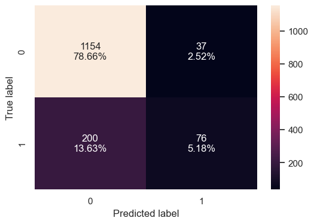

```python
# Confusion matrix for test data
confusion_matrix_sklearn(abc, X_test, y_test)
```

**Observations**

- *The AdaBoost Clasifier is well generalized for all the metric scores, however the Recall is very low.*
- *Recall score for Train and Test Data are 0.287 and 0.275 respectively*

### Model Improvement: AdaBoost

```python
# Initialize AdaBoost classifier.
abc_tuned = AdaBoostClassifier(random_state=1)

# Grid of parameters to choose from
parameters = {
    # different max_depth for base_estimator
    "base_estimator": [
        DecisionTreeClassifier(max_depth=1),
        DecisionTreeClassifier(max_depth=2),
        DecisionTreeClassifier(max_depth=3),
    ],
    "n_estimators": np.arange(10, 110, 10),
    "learning_rate": np.arange(0.1, 2, 0.1),
}

# Type of scoring used to compare parameter  combinations
acc_scorer = metrics.make_scorer(metrics.recall_score)

# Run the grid search
grid_obj = GridSearchCV(abc_tuned, parameters, scoring=acc_scorer, cv=5)
grid_obj = grid_obj.fit(X_train, y_train)

# Set the clf to the best combination of parameters
abc_tuned = grid_obj.best_estimator_

# Complete the code to fit the above model on training data
abc_tuned.fit(X_train, y_train)
```

```
AdaBoostClassifier(base_estimator=DecisionTreeClassifier(max_depth=3),
                   learning_rate=1.5000000000000002, n_estimators=100,
                   random_state=1)
```

### Model Performance Check

#### Checking model performance on training set

```python
# Calculating different metrics
abc_tuned_model_train_perf = model_performance_classification_sklearn(
    abc_tuned, X_train, y_train
)
print("Training performance:")
abc_tuned_model_train_perf
```

```
Training performance:
```

|  | Accuracy | Recall | Precision | F1 |
| --- | --- | --- | --- | --- |
| 0 | 0.9696 | 0.892857 | 0.942623 | 0.917065 |

#### Checking model performance on testing set

```python
# get the model performance on X_test and y_test using the above model
abc_tuned_model_test_perf = model_performance_classification_sklearn(
    abc_tuned, X_test, y_test
)
print("Testing performance:")
abc_tuned_model_test_perf
```

```
Testing performance:
```

|  | Accuracy | Recall | Precision | F1 |
| --- | --- | --- | --- | --- |
| 0 | 0.861622 | 0.594203 | 0.643137 | 0.617702 |

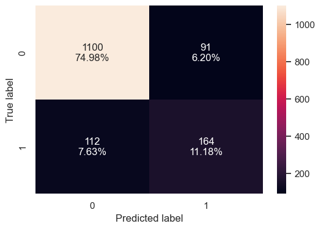

```python
# Confusion matrix for test data
confusion_matrix_sklearn(abc_tuned, X_test, y_test)
```

### Model Building: Gradient Boost

```python
# Build Gradient Boost Classifier Model
gbc = GradientBoostingClassifier(random_state=1)

## Fit the Gradient Boost model on X_train and y_train
gbc.fit(X_train, y_train)
```

```
GradientBoostingClassifier(random_state=1)
```

### Model Performance Check

#### Checking model performance on training set

```python
# Calculating different metrics
gbc_model_train_perf = model_performance_classification_sklearn(gbc, X_train, y_train)
print("Training performance:")
gbc_model_train_perf
```

```
Training performance:
```

|  | Accuracy | Recall | Precision | F1 |
| --- | --- | --- | --- | --- |
| 0 | 0.87869 | 0.43323 | 0.848024 | 0.573484 |

#### Checking model performance on testing set

```python
# get the model performance on X_test and y_test using the above model
gbc_model_test_perf = model_performance_classification_sklearn(gbc, X_test, y_test)
print("Testing performance:")
gbc_model_test_perf
```

```
Testing performance:
```

|  | Accuracy | Recall | Precision | F1 |
| --- | --- | --- | --- | --- |
| 0 | 0.859577 | 0.358696 | 0.773438 | 0.490099 |

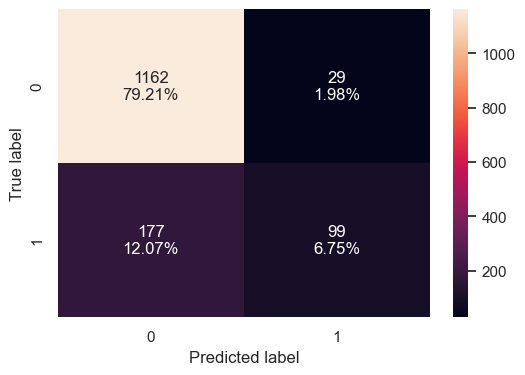

```python
# Confusion matrix for test data
confusion_matrix_sklearn(gbc, X_test, y_test)
```

**Observations**

- *The Gradient Clasifier is generalized for training data, however the Recall is very low.*
- *Recall score for Train and Test Data are 0.433 and 0.359 respectively*

### Model Improvement: Gradient Boost

```python
# Initialize classifier.
gbc_tuned = GradientBoostingClassifier(
    init=AdaBoostClassifier(random_state=1), random_state=1
)

# Grid of parameters to choose from
parameters = {
    "n_estimators": [100, 150, 200, 250],
    "subsample": [0.8, 0.9, 1],
    "max_features": [0.7, 0.8, 0.9, 1],
}

# Type of scoring used to compare parameter combinations
acc_scorer = metrics.make_scorer(metrics.recall_score)

# Run the grid search
grid_obj = GridSearchCV(gbc_tuned, parameters, scoring=acc_scorer, cv=5)
grid_obj = grid_obj.fit(X_train, y_train)

# Set the clf to the best combination of parameters
gbc_tuned = grid_obj.best_estimator_

# Complete the code to fit the above model on training data
gbc_tuned.fit(X_train, y_train)
```

```
GradientBoostingClassifier(init=AdaBoostClassifier(random_state=1),
                           max_features=0.8, n_estimators=250, random_state=1,
                           subsample=1)
```

### Model Performance Check

#### Checking model performance on training set

```python
# Calculating different metrics
gbc_tuned_model_train_perf = model_performance_classification_sklearn(
    gbc_tuned, X_train, y_train
)
print("Training performance:")
gbc_tuned_model_train_perf
```

```
Training performance:
```

|  | Accuracy | Recall | Precision | F1 |
| --- | --- | --- | --- | --- |
| 0 | 0.908214 | 0.565217 | 0.914573 | 0.698656 |

#### Checking model performance on testing set

```python
# get the model performance on X_test and y_test using the above model
gbc_tuned_model_test_perf = model_performance_classification_sklearn(
    gbc_tuned, X_test, y_test
)
print("Testing performance:")
gbc_tuned_model_test_perf
```

```
Testing performance:
```

|  | Accuracy | Recall | Precision | F1 |
| --- | --- | --- | --- | --- |
| 0 | 0.877301 | 0.452899 | 0.811688 | 0.581395 |

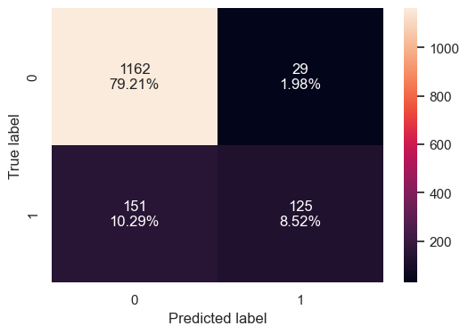

```python
# Confusion matrix for test data
confusion_matrix_sklearn(gbc_tuned, X_test, y_test)
```

**Observations**

- *The Gradient Boost Clasifier is generalized for training data, and the Recall has improved, though still average.*
- *Recall score for Train and Test Data are 0.565 and 0.453 respectively*

### Model Building: XGBoost

```python
# Fitting the model
xgb = XGBClassifier(random_state=1, eval_metric="logloss")
xgb.fit(X_train, y_train)
```

```
XGBClassifier(base_score=None, booster=None, callbacks=None,
              colsample_bylevel=None, colsample_bynode=None,
              colsample_bytree=None, early_stopping_rounds=None,
              enable_categorical=False, eval_metric='logloss',
              feature_types=None, gamma=None, gpu_id=None, grow_policy=None,
              importance_type=None, interaction_constraints=None,
              learning_rate=None, max_bin=None, max_cat_threshold=None,
              max_cat_to_onehot=None, max_delta_step=None, max_depth=None,
              max_leaves=None, min_child_weight=None, missing=nan,
              monotone_constraints=None, n_estimators=100, n_jobs=None,
              num_parallel_tree=None, predictor=None, random_state=1, ...)
```

### Model Performance Check

#### Checking model performance on training set

```python
# Calculating different metrics
xgb_model_train_perf = model_performance_classification_sklearn(xgb, X_train, y_train)

print("Training performance:")
xgb_model_train_perf
```

```
Training performance:
```

|  | Accuracy | Recall | Precision | F1 |
| --- | --- | --- | --- | --- |
| 0 | 0.997077 | 0.984472 | 1.0 | 0.992175 |

#### Checking model performance on testing set

```python
# get the model performance on X_test and y_test using the above model
xgb_model_test_perf = model_performance_classification_sklearn(xgb, X_test, y_test)

print("Testing performance:")
xgb_model_test_perf
```

```
Testing performance:
```

|  | Accuracy | Recall | Precision | F1 |
| --- | --- | --- | --- | --- |
| 0 | 0.903885 | 0.594203 | 0.849741 | 0.69936 |

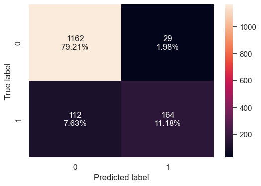

```python
# Confusion matrix for test data
confusion_matrix_sklearn(xgb, X_test, y_test)
```

**Observations**

- *The Gradient Boost Clasifier the Recall has improved, but the model is still overfitting.*
- *Recall score for Train and Test Data are 0.984 and 0.594 respectively*

### Model Improvement: XGBoost

```python
# Initialize classifier.
xgb_tuned = XGBClassifier(random_state=1, eval_metric="logloss")

# Grid of parameters to choose from
parameters = {
    "n_estimators": [10, 30, 50],
    "scale_pos_weight": [1, 2, 5],
    "subsample": [0.7, 0.9, 1],
    "learning_rate": [0.05, 0.1, 0.2],
    "colsample_bytree": [0.7, 0.9, 1],
    "colsample_bylevel": [0.5, 0.7, 1],
}

# Type of scoring used to compare parameter combinations
scorer = metrics.make_scorer(metrics.recall_score)

# Run the grid search
grid_obj = GridSearchCV(xgb_tuned, parameters, scoring=scorer, cv=5)
grid_obj = grid_obj.fit(X_train, y_train)

# Set the clf to the best combination of parameters
xgb_tuned = grid_obj.best_estimator_

# Fit the best algorithm to the data.
xgb_tuned.fit(X_train, y_train)
```

```
XGBClassifier(base_score=None, booster=None, callbacks=None,
              colsample_bylevel=0.7, colsample_bynode=None,
              colsample_bytree=0.9, early_stopping_rounds=None,
              enable_categorical=False, eval_metric='logloss',
              feature_types=None, gamma=None, gpu_id=None, grow_policy=None,
              importance_type=None, interaction_constraints=None,
              learning_rate=0.2, max_bin=None, max_cat_threshold=None,
              max_cat_to_onehot=None, max_delta_step=None, max_depth=None,
              max_leaves=None, min_child_weight=None, missing=nan,
              monotone_constraints=None, n_estimators=30, n_jobs=None,
              num_parallel_tree=None, predictor=None, random_state=1, ...)
```

### Model Performance Check

#### Checking model performance on training set

```python
# Calculating different metrics
xgb_tuned_model_train_perf = model_performance_classification_sklearn(
    xgb_tuned, X_train, y_train
)

print("Training performance:")
xgb_tuned_model_train_perf
```

```
Training performance:
```

|  | Accuracy | Recall | Precision | F1 |
| --- | --- | --- | --- | --- |
| 0 | 0.918445 | 0.944099 | 0.714454 | 0.813378 |

#### Checking model performance on testing set

```python
# get the model performance on X_test and y_test using the above model
xgb_tuned_model_test_perf = model_performance_classification_sklearn(
    xgb_tuned, X_test, y_test
)

print("Testing performance:")
xgb_tuned_model_test_perf
```

```
Testing performance:
```

|  | Accuracy | Recall | Precision | F1 |
| --- | --- | --- | --- | --- |
| 0 | 0.842536 | 0.771739 | 0.559055 | 0.648402 |

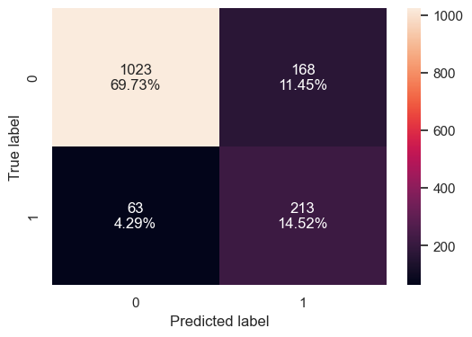

```python
# Confusion matrix for test data
confusion_matrix_sklearn(xgb_tuned, X_test, y_test)
```

### Reworking: XGBoost

```python
# Initialize classifier.
xgb4 = XGBClassifier(random_state=1, eval_metric="logloss")

# Grid of parameters to choose from
parameters = {
    "n_estimators": np.arange(50, 150, 50),
    "scale_pos_weight": [2, 5, 10],
    "learning_rate": [0.01, 0.1, 0.2, 0.05],
    "gamma": [0, 1, 3, 5],
    "subsample": [0.8, 0.9, 1],
    "max_depth": np.arange(1, 5, 1),
    "reg_lambda": [5, 10],
}

# Type of scoring used to compare parameter combinations
scorer = metrics.make_scorer(metrics.recall_score)

# Run the grid search
grid_obj = GridSearchCV(xgb4, parameters, scoring=scorer, cv=5)
grid_obj = grid_obj.fit(X_train, y_train)

# Set the clf to the best combination of parameters
xgb4 = grid_obj.best_estimator_

# Fit the best algorithm to the data.
xgb4.fit(X_train, y_train)
```

```
XGBClassifier(base_score=None, booster=None, callbacks=None,
              colsample_bylevel=None, colsample_bynode=None,
              colsample_bytree=None, early_stopping_rounds=None,
              enable_categorical=False, eval_metric='logloss',
              feature_types=None, gamma=0, gpu_id=None, grow_policy=None,
              importance_type=None, interaction_constraints=None,
              learning_rate=0.01, max_bin=None, max_cat_threshold=None,
              max_cat_to_onehot=None, max_delta_step=None, max_depth=1,
              max_leaves=None, min_child_weight=None, missing=nan,
              monotone_constraints=None, n_estimators=50, n_jobs=None,
              num_parallel_tree=None, predictor=None, random_state=1, ...)
```

### Model Building: Stacking

```python
# Initializing different models
estimators = [
    ("Decision Tree", tuned_dtree),
    ("Gradient Boosting", gbc_tuned),
    ("Random Forest", rf_tuned),
]
final_estimator = xgb_tuned

stacking_classifier = StackingClassifier(
    estimators=estimators, final_estimator=final_estimator
)

stacking_classifier.fit(X_train, y_train)
```

```
StackingClassifier(estimators=[('Decision Tree',
                                DecisionTreeClassifier(class_weight={0: 0.19,
                                                                     1: 0.81},
                                                       max_depth=13,
                                                       min_impurity_decrease=0.001,
                                                       random_state=1)),
                               ('Gradient Boosting',
                                GradientBoostingClassifier(init=AdaBoostClassifier(random_state=1),
                                                           max_features=0.8,
                                                           n_estimators=250,
                                                           random_state=1,
                                                           subsample=1)),
                               ('Random Forest',
                                RandomForestClassifier(clas...
                                                 gpu_id=None, grow_policy=None,
                                                 importance_type=None,
                                                 interaction_constraints=None,
                                                 learning_rate=0.2,
                                                 max_bin=None,
                                                 max_cat_threshold=None,
                                                 max_cat_to_onehot=None,
                                                 max_delta_step=None,
                                                 max_depth=None,
                                                 max_leaves=None,
                                                 min_child_weight=None,
                                                 missing=nan,
                                                 monotone_constraints=None,
                                                 n_estimators=30, n_jobs=None,
                                                 num_parallel_tree=None,
                                                 predictor=None, random_state=1, ...))
```

### Model Performance Check

#### Checking model performance on training set

```python
# Calculating different metrics
stacking_classifier_model_train_perf = model_performance_classification_sklearn(
    stacking_classifier, X_train, y_train
)

print("Training performance:")
stacking_classifier_model_train_perf
```

```
Training performance:
```

|  | Accuracy | Recall | Precision | F1 |
| --- | --- | --- | --- | --- |
| 0 | 0.845951 | 0.90528 | 0.555767 | 0.688718 |

#### Checking model performance on testing set

```python
# get the model performance on X_test and y_test using the above model
stacking_classifier_model_test_perf = model_performance_classification_sklearn(
    stacking_classifier, X_test, y_test
)

print("Testing performance:")
stacking_classifier_model_test_perf
```

```
Testing performance:
```

|  | Accuracy | Recall | Precision | F1 |
| --- | --- | --- | --- | --- |
| 0 | 0.798909 | 0.786232 | 0.479029 | 0.595336 |

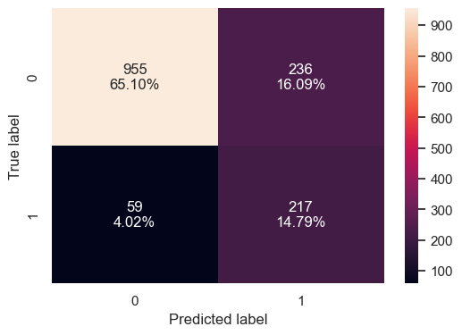

```python
# Confusion matrix for test data
confusion_matrix_sklearn(stacking_classifier, X_test, y_test)
```

## **Model Comparison and Final Model Selection**

```python
# Model performance comparison for training data

# Combine all the model performance on training data into a single dataframe
models_train_comp_df = pd.concat(
    [
        d_tree_model_train_perf.T,
        tuned_dtree_estimator_model_train_perf.T,
        rfc_model_train_perf.T,
        rf_tuned_model_train_perf.T,
        bgc_model_train_perf.T,
        bgc_tuned_model_train_perf.T,
        abc_model_train_perf.T,
        abc_tuned_model_train_perf.T,
        gbc_model_train_perf.T,
        gbc_tuned_model_train_perf.T,
        xgb_model_train_perf.T,
        xgb_tuned_model_train_perf.T,
        stacking_classifier_model_train_perf.T,
    ],
    axis=1,
)
# Set the column titles
models_train_comp_df.columns = [
    "Decision Tree",
    "Decision Tree Tuned",
    "Random Forest",
    "Random Forest Tuned",
    "Bagging Classifier",
    "Bagging Estimator Tuned",
    "Adaboost Classifier",
    "Adaboost Classifier Tuned",
    "Gradient Boost Classifier",
    "Gradient Boost Classifier Tuned",
    "XGBoost Classifier",
    "XGBoost Classifier Tuned",
    "Stacking Classifier",
]

print("Training performance comparison:")
display(models_train_comp_df)


# Model performance comparison for testing data

# Combine all the model performance on testing data into a single dataframe
models_test_comp_df = pd.concat(
    [
        d_tree_model_test_perf.T,
        tuned_dtree_estimator_model_test_perf.T,
        rfc_model_test_perf.T,
        rf_tuned_model_test_perf.T,
        bgc_model_test_perf.T,
        bgc_tuned_model_test_perf.T,
        abc_model_test_perf.T,
        abc_tuned_model_test_perf.T,
        gbc_model_test_perf.T,
        gbc_tuned_model_test_perf.T,
        xgb_model_test_perf.T,
        xgb_tuned_model_test_perf.T,
        stacking_classifier_model_test_perf.T,
    ],
    axis=1,
)
# Set the column titles
models_test_comp_df.columns = [
    "Decision Tree",
    "Decision Tree Tuned",
    "Random Forest",
    "Random Forest Tuned",
    "Bagging Classifier",
    "Bagging Estimator Tuned",
    "Adaboost Classifier",
    "Adaboost Classifier Tuned",
    "Gradient Boost Classifier",
    "Gradient Boost Classifier Tuned",
    "XGBoost Classifier",
    "XGBoost Classifier Tuned",
    "Stacking Classifier",
]
print("\n")
print("Testing performance comparison:")
display(models_test_comp_df)
```

```
Training performance comparison:
```

|  | Decision Tree | Decision Tree Tuned | Random Forest | Random Forest Tuned | Bagging Classifier | Bagging Estimator Tuned | Adaboost Classifier | Adaboost Classifier Tuned | Gradient Boost Classifier | Gradient Boost Classifier Tuned | XGBoost Classifier | XGBoost Classifier Tuned | Stacking Classifier |
| --- | --- | --- | --- | --- | --- | --- | --- | --- | --- | --- | --- | --- | --- |
| Accuracy | 1.0 | 0.813505 | 1.0 | 0.849752 | 0.905875 | 0.910845 | 0.850044 | 0.969600 | 0.878690 | 0.908214 | 0.997077 | 0.918445 | 0.845951 |
| Recall | 1.0 | 0.933230 | 1.0 | 0.821429 | 0.928571 | 0.889752 | 0.287267 | 0.892857 | 0.433230 | 0.565217 | 0.984472 | 0.944099 | 0.905280 |
| Precision | 1.0 | 0.502508 | 1.0 | 0.570043 | 0.684211 | 0.710037 | 0.774059 | 0.942623 | 0.848024 | 0.914573 | 1.000000 | 0.714454 | 0.555767 |
| F1 | 1.0 | 0.653261 | 1.0 | 0.673028 | 0.787879 | 0.789800 | 0.419026 | 0.917065 | 0.573484 | 0.698656 | 0.992175 | 0.813378 | 0.688718 |

```
Testing performance comparison:
```

|  | Decision Tree | Decision Tree Tuned | Random Forest | Random Forest Tuned | Bagging Classifier | Bagging Estimator Tuned | Adaboost Classifier | Adaboost Classifier Tuned | Gradient Boost Classifier | Gradient Boost Classifier Tuned | XGBoost Classifier | XGBoost Classifier Tuned | Stacking Classifier |
| --- | --- | --- | --- | --- | --- | --- | --- | --- | --- | --- | --- | --- | --- |
| Accuracy | 0.864349 | 0.760736 | 0.889571 | 0.815269 | 0.850034 | 0.848671 | 0.838446 | 0.861622 | 0.859577 | 0.877301 | 0.903885 | 0.842536 | 0.798909 |
| Recall | 0.663043 | 0.789855 | 0.467391 | 0.695652 | 0.699275 | 0.644928 | 0.275362 | 0.594203 | 0.358696 | 0.452899 | 0.594203 | 0.771739 | 0.786232 |
| Precision | 0.633218 | 0.426614 | 0.895833 | 0.506596 | 0.584848 | 0.589404 | 0.672566 | 0.643137 | 0.773438 | 0.811688 | 0.849741 | 0.559055 | 0.479029 |
| F1 | 0.647788 | 0.554003 | 0.614286 | 0.586260 | 0.636964 | 0.615917 | 0.390746 | 0.617702 | 0.490099 | 0.581395 | 0.699360 | 0.648402 | 0.595336 |

**Observations**

- *The `Tuned Decision Tree`, the `Tuned XGBoost` and the `Stacking Classifier` Models gives us Best RECALL Score on Testing data; 0.789855, 0.771739 & 0.786232 respectively.*
- *However, the `Stacking Classifier` is the most generarized model of the three models followed by `Tuned Decision Tree`.*
- *Since our objective is to Maximize `The Recall Score` and achieving `good generalization`, The `Stacking Classifier` Model will be proposed to the Customer.*
- *We will draw inferences for the Important Feature from both The `Stacking Classifier` and `Tuned Decision Tree` models.*

### Stacking: Important Features

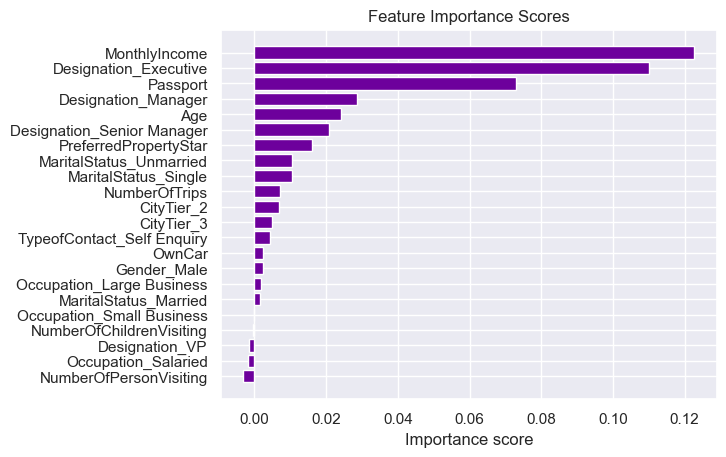

```python
result = permutation_importance(
    stacking_classifier, X_test, y_test, n_repeats=10, random_state=1
)

# Sort feature importance scores
sorted_idx = result.importances_mean.argsort()[::-1]
importances_sorted = result.importances_mean[sorted_idx]
feature_names_sorted = np.array(feature_names)[sorted_idx]

# Plot feature importance scores
fig, ax = plt.subplots()
ax.barh(np.arange(X.shape[1]), importances_sorted)
ax.invert_yaxis()
ax.set_yticks(np.arange(X.shape[1]))
ax.set_yticklabels(feature_names_sorted)
ax.set_xlabel("Importance score")
ax.set_title("Feature Importance Scores")
plt.show()
```

**Observations**

- *Looking at feature importance of the `Stacking Classifier`, `MonthlyIncome`, `Designation` & `Passport` are most important features.*
- *`NumberOfChildrenVisiting` and `NumberOfPersonVisiting`, seem to be insignificant.*

### Tuned Decision Tree: Important Features

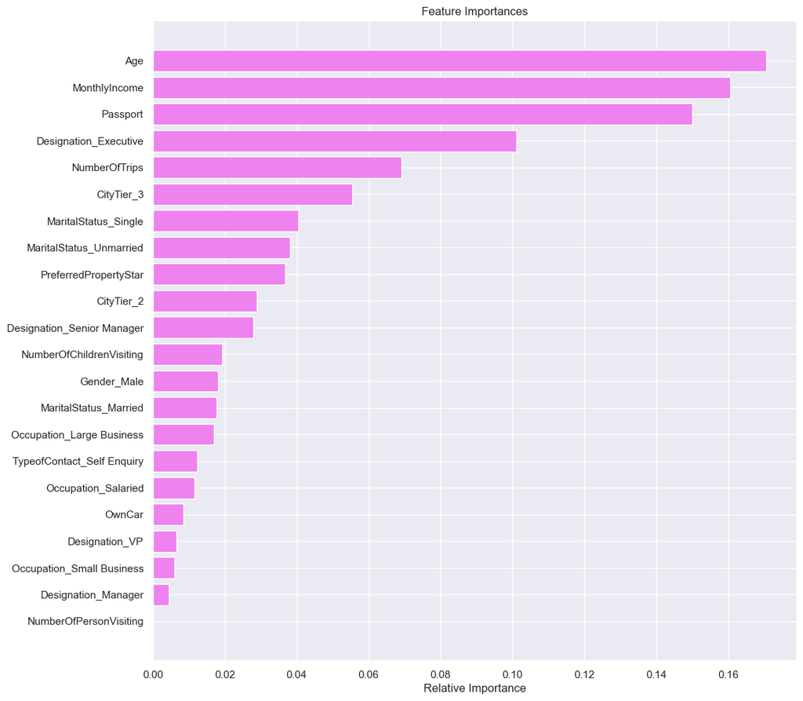

```python
feature_names = X_train.columns
importances = tuned_dtree.feature_importances_
indices = np.argsort(importances)

plt.figure(figsize=(12, 12))
plt.title("Feature Importances")
plt.barh(range(len(indices)), importances[indices], color="violet", align="center")
plt.yticks(range(len(indices)), [feature_names[i] for i in indices])
plt.xlabel("Relative Importance")
plt.show()
```

**Observations**

- *Looking at feature importance the `Tuned Decision Tree`, `Age`, `MonthlyIncome`, `Passport` & `Designation_Executive` are most important features.*
- *`NumberOfPersonVisiting`, `Designation_Manager` and `Occupation_SmallBusiness`, seem to be insignificant.*

**CONCLUSION**

- *We have succcessfully built, trained and tested 13 models: "Decision Tree", "Decision Tree Tuned", "Random Forest", "Random Forest Tuned", "Bagging Classifier", "Bagging Classifier Tuned", "Adaboost Classifier", "Adaboost Classifier Tuned","Gradient Boost Classifier", "Gradient Boost Classifier Tuned", "XGBoost Classifier", "XGBoost Classifier Tuned" and "Stacking Classifier".*
- *We propose that the Stacking Model can be used by **Visit With Us** in their "Travel Package Purchase Campaign" to predict if a customer will purchase the new product: **Wellness Tourism Package**.*

# **Insights & Recommendations**

## **Recomendations to the Business**

Based on the Predictive Models, Analysis, Insights & Observations...here are specific business recommendations:

1. *The **Wellness Tourism Package** should be curated to target Customers that are **flexible**: Singles, Young, Ummarried and Freelancers.*
2. *The business should come up with a **"Family Package"** to increase the percentage of Married customers that signup.*

   ◎ The company can run various campaigns and offers (discounts, coupons, etc...) for customers with family to increase sales.
3. *Specific packages can be created for different income segments.*
4. *The business should create product and customer segment specific sale pitch to reduce and standardize the Duration of Pitch.*
5. *Based on the fact that data shows that customers with passports have a higher buying percentage:*

   ◎ The business should craft international packages for, and target such customers.

   ◎ The business should should help and promote customers to get a passport.

**Further Analysis and Modeling:**

1. *Our analysis shows that a key missing component is the inability to tell if the Product pitched was the same product that was bought and that what product was targeted to specific groups if any.*

   ◎ We recommend that further data collection should be done to capture additional information like customer satisfaction post tour and data to correlate the product pitched to the product actually purchased by customers.

   ◎ Further analysis & modelling needs to be done to unearth these invaluable information.
2. *We recommend that further analysis be done to see if the **Wellness Tourism Package** has any similar features with existing packages. This will help in building a customer profile, thereby ensuring specific customer segmentation and targeted base.*